# The differences between members and customers on different bike types

## Investigation Overview

In this investigation, I wanted to look at the differences between the member trips and the customer trips, the differences between the electric bike trips and the docked bike trips. Based on the trip counts, the durations and the start times.

## Dataset Overview

This document explores a dataset containing ride_id and other aspects of a trip for approximately 138,000 bike trips in 05/20 from Lyft.There are 138251 trips in the dataset with 14 features ('ride_id', 'rideable_type', 'started_at', 'ended_at', 'start_station_name', 'start_station_id', 'end_station_name','end_station_id', 'start_lat', 'start_lng', 'end_lat', 'end_lng','member_casual', 'is_equity'). Only four variables are numeric in nature, the rest of them are all categorical including the start_station_id and end_station_id.

## Distribution of trip durations (Mins)

There are almsot 80% of the trips fall in 30 mins. When the duration increads, the trips accordingly decreases.

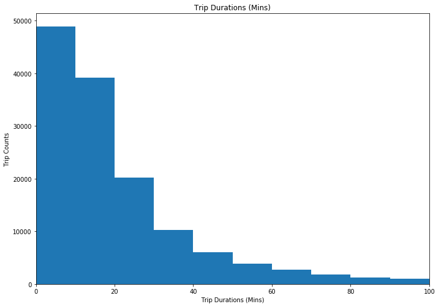

```python
# For a closer look
binsize = 10
bins = np.arange(0, df_2005.duration.max()+binsize, binsize)
plt.figure(figsize=[ 11.69, 8.27])
plt.hist(data = df_2005, x = 'duration', bins = bins);
plt.xlim(0, 100);
plt.title('Trip Durations (Mins)');
plt.xlabel('Trip Durations (Mins)');
plt.ylabel('Trip Counts');
```

# Distribution of the trip started times

Around 5pm to 6pm is the peak, the most trips happen this time, and from 2am to 5am has the least trips.

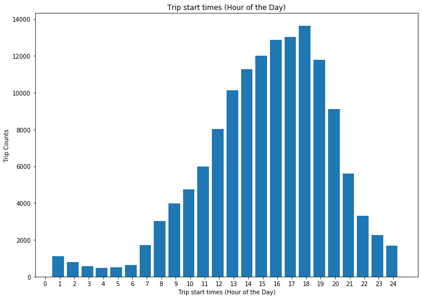

```python
plt.figure(figsize=[ 11.69, 8.27])
time_bins = range(0, 25)
plt.hist(data = df_2005, x = "started_time", bins = time_bins, align='right', width=0.8);
plt.xticks(time_bins, time_bins);
plt.title('Trip start times (Hour of the Day)');
plt.xlabel('Trip start times (Hour of the Day)');
plt.ylabel('Trip Counts');
```

# Trip durations VS Trip started times

The trip duration gets its peak at around 12pm. Overall the trips after 12pm have a bigger duration than the ones before 12pm, and have more longer duration trips.

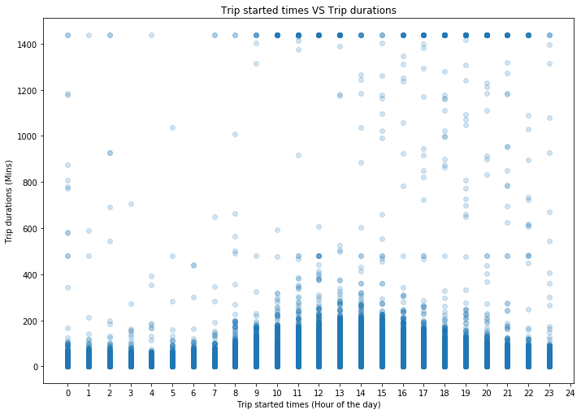

```python
plt.figure(figsize=[ 11.69, 8.27])
plt.scatter(data = df_2005, x = 'started_time', y = 'duration', alpha = 1/5);
plt.xticks(time_bins, time_bins);
plt.title('Trip started times VS Trip durations');
plt.xlabel('Trip started times (Hour of the day)');
plt.ylabel('Trip durations (Mins)');
```

# Started latitude VS Ended latitude

All trips start from two main lantitude: one is around 37.3, another is around 37.8. There are more trips happen around 37.8. Lantitude 37.7-37.9 is the main area where trips stopped.

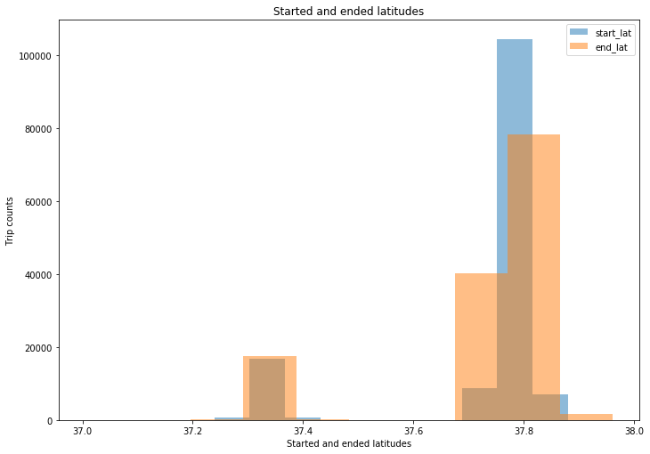

```python
plt.figure(figsize=[ 11.69, 8.27])
plt.hist(data = df_2005, x = 'start_lat', label = 'start_lat',  alpha = 0.5);
plt.hist(data = df_2005, x = 'end_lat', label = 'end_lat',  alpha = 0.5);
plt.legend(loc = 'best');
plt.title('Started and ended latitudes');
plt.xlabel('Started and ended latitudes');
plt.ylabel('Trip counts');
plt.show();
```

# Trip durations on bike types and customer types(members or customers)

The number of member trips is much less than the number of customer trips. For electric_bike, there's no big difference of the distribution of customer and member, just the trip amount of customer is two times than member. For docked_bike, the trip amount is almost the same, but not like member, the customer prefers longer trips.

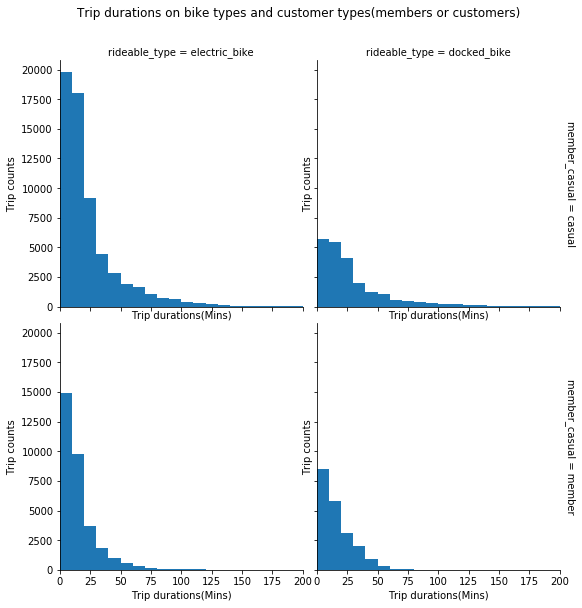

```python
g = sb.FacetGrid(data = df_2005, col = 'rideable_type', row = 'member_casual',margin_titles= True, size = 4);
g.map(plt.hist, 'duration', bins = bins);
plt.xlim(0, 200);

plt.suptitle('Trip durations on bike types and customer types(members or customers)', y = 1.05);
g.set(ylabel = 'Trip counts', xlabel = 'Trip durations(Mins)');
```

# Trip durations and trip started times on bike types

Overall the docked_bike trips last longer than the electic_bike trips. There are a lot of docked_bike trips acually last 1400 mins. There's no big difference for the electric_bike trips durations according the start time, however, it's not the same for docked_bike trips.

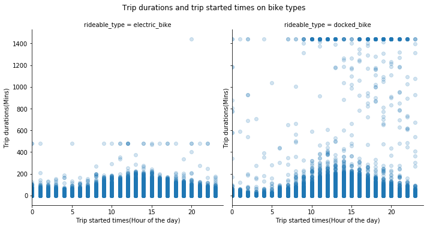

```python
g = sb.FacetGrid(data = df_2005, col = 'rideable_type', margin_titles= True, size=5);
g.map(plt.scatter, 'started_time', 'duration', alpha = 1/5);
plt.xlim(0, 24);
plt.suptitle('Trip durations and trip started times on bike types', y = 1.05);
g.set(ylabel = 'Trip durations(Mins)', xlabel = 'Trip started times(Hour of the day)');
```

# Trip duratioins and trip started times on customer types

The durations for customer trips are longer than member trips durations, this is may becuase that we have more customer trips. But the members trips have more superlong trips around 1400 mins, and evenly distributed according the start times.

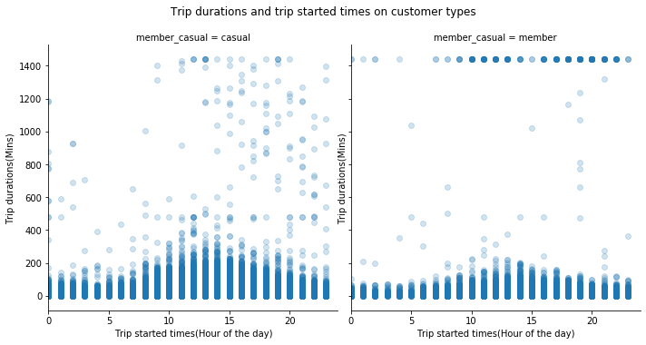

```python
g = sb.FacetGrid(data = df_2005, col = 'member_casual', margin_titles= True, size=5);
g.map(plt.scatter, 'started_time', 'duration', alpha = 1/5);
plt.xlim(0, 24);
plt.suptitle('Trip durations and trip started times on customer types', y = 1.05);
g.set(ylabel = 'Trip durations(Mins)', xlabel = 'Trip started times(Hour of the day)');
```